# Intra-cycle detrending

This notebook demonstrates how to use `detrend1d` to perform intra-cycle detrending. "Intra-cycle" implies that a given trend can be variable within each cycle. Consider two points at 25% and 75% of a given cycle. It is possible that the first point's value *increases* over time, and that the second point's value *decreases* over time. The presence of such a trend may be undesireable in certain situations, especially when estimating and comparing cycle means, becuase the presence of a trend generally means greater variability with respect to the mean.

In addition to **inter-cycle** (i.e., whole time-series) trend estimation and removal, `detrend1d` can also be used to estimate and remove **intra-cycle** trends. The easiest way to do achieve this is with the `detrend1d.detrend_intracycle` function. Before considering that function, let's first load a time series that has an intra-cycle trend.

```python
import os
import numpy as np
import matplotlib.pyplot as plt
import detrend1d as dtr
```

# Part 1: A dataset with an intra-cycle trend

The attached "knee_flexion.csv" file contains synthetic knee flexion data during walking and consists of three columns:

- `t` = time (s)
- `y` = knee flexion (deg)
- `c` = cycle index

The `c` variable indicates which time point pertains belongs to which cycle. Let's load and visualize these data.

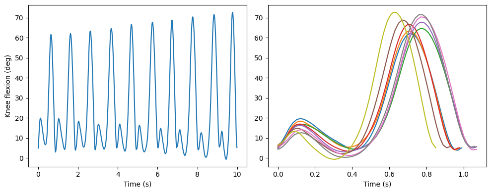

```python
dirDATA = os.path.join( os.path.split( os.getcwd() )[0], 'Data' )
fpath   = os.path.join(dirDATA, 'knee_flexion.csv')
t,y,c   = np.loadtxt(fpath, delimiter=',', skiprows=1).T


fig,axs = plt.subplots(1, 2, figsize=(10,4), tight_layout=True)
ax0,ax1 = axs
ax0.plot(t, y, label='Original data')
ncycles = int( c.max() )
for i in range(1, ncycles):
    tt,yy  = t[c==(i+1)], y[c==(i+1)]
    ax1.plot(tt-tt[0], yy)
[ax.set_xlabel('Time (s)')  for ax in axs]
ax0.set_ylabel('Knee flexion (deg)')
plt.show()
```

A general trend of increasing maximum values is apparent in the left-hand figure above, but to make a potential **intra-cycle** trend clearer, it is useful to use colors to indicate increasing time, like this:

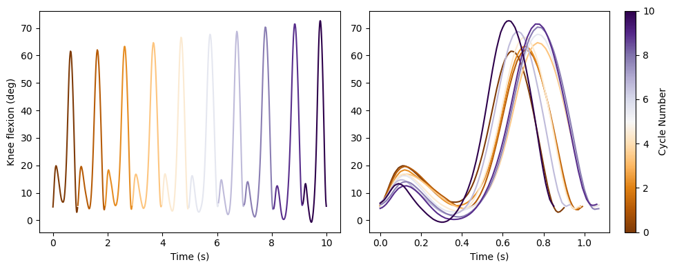

```python
fig,axs = plt.subplots(1, 2, figsize=(10,4), tight_layout=True)
ax0,ax1 = axs
ncycles = int( c.max() )
cmap    = plt.cm.PuOr
colors  = cmap( np.linspace(0, 1, ncycles) )

for i,color in enumerate(colors):
    tt,yy  = t[c==(i+1)], y[c==(i+1)]
    ax0.plot(tt, yy, color=color)
    ax1.plot(tt-tt[0], yy, color=color)
[ax.set_xlabel('Time (s)')  for ax in axs]
ax0.set_ylabel('Knee flexion (deg)')
# add colorbar
norm   = plt.Normalize(vmin=0, vmax=ncycles)
sm     = plt.cm.ScalarMappable(cmap=cmap, norm=norm)
cb     = plt.colorbar(sm, ax=ax1)
cb.set_label( 'Cycle Number' )
plt.show()
```

Intra-cycle trends can become even clearer after *registering* (i.e., temporally normalizing) the cycles. Simple linear registration can be conducted using `detrend1d.reg.interp_n`, a convenience function that linearly interpolates a given 1D array to a given number of points. Here let's interpolate to 101 points.

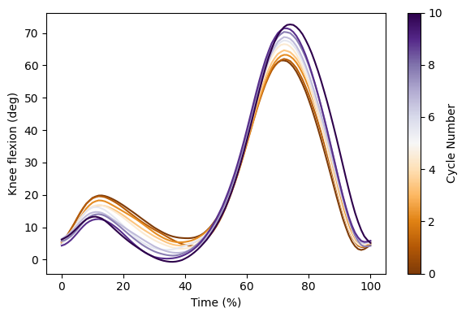

```python
fig     = plt.figure(figsize=(6,4), tight_layout=True)
ax      = plt.axes()
ncycles = int( c.max() )
cmap    = plt.cm.PuOr
colors  = cmap( np.linspace(0, 1, ncycles) )
for i,color in enumerate(colors):
    tt,yy  = t[c==(i+1)], y[c==(i+1)]
    yyi    = dtr.reg.interp_n(yy, 101)
    ax.plot(yyi, color=color)
ax.set_xlabel('Time (%)')
ax.set_ylabel('Knee flexion (deg)')
norm    = plt.Normalize(vmin=0, vmax=ncycles)
sm      = plt.cm.ScalarMappable(cmap=cmap, norm=norm)
cb      = plt.colorbar(sm, ax=ax)
cb.set_label( 'Cycle Number' )
plt.show()
```

Note that the intra-cycle trend changes from a *negative* trend at around time=15% to a *positive* trend at around time=75%.

# Part 2: Intra-cycle detrending

Let's use `detrend1d.detrend_intracycle` to detrend this dataset.

```python
t,y,c  = np.loadtxt(fpath, delimiter=',', skiprows=1).T
yd,fit  = dtr.detrend_intracycle(t, y, c, trend='linear')

print( type(yd) )
print( y.shape, yd.shape )
print()
print( fit )
```

```
<class 'numpy.ndarray'>
(1000,) (1000,)

CyclicalFit
   trend_type:  linear
   beta:        (2, 101) array
   t:          (1000,) time array
   y:          (1000,) dependent variable array
   yhat:       (1000,) fitted values array
```

The first output is a detrended, one-dimensional numpy array that is the same size as the original data array.

The second output is a `CyclicalFit` object that contains the trend parameters. Note that `beta` is a 2D array, containing two parameters ($b_0$ and $b_1$) at each point across a 101-point cycle.

A convenient way to visualize the intra-cycle trend is to use the `plot_timeseries_with_trend` method of the `fit` object, which automatically highlights the points with the maximum positive and maximum negative trends:

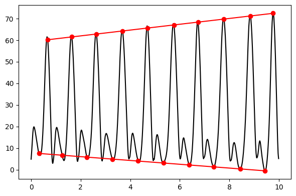

```python
fig = plt.figure(figsize=(6,4), tight_layout=True)
ax  = plt.axes()
fit.plot_timeseries_with_trend( ax=ax )
plt.show()
```

The detrended data can be visualized as a normal numpy array:

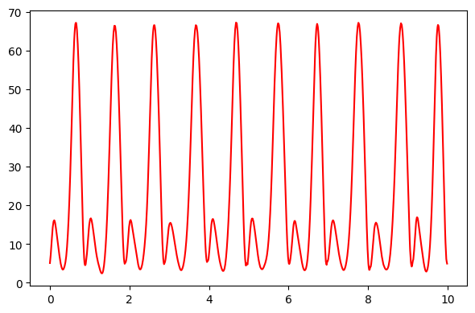

```python
fig = plt.figure(figsize=(6,4), tight_layout=True)
ax  = plt.axes()
ax.plot(t, yd, 'r', label='Detrended')
plt.show()
```

Note that the general trends appear to be absent or at least much less pronounced.

The effects of detrending can be further visualized by comparing to the original data:

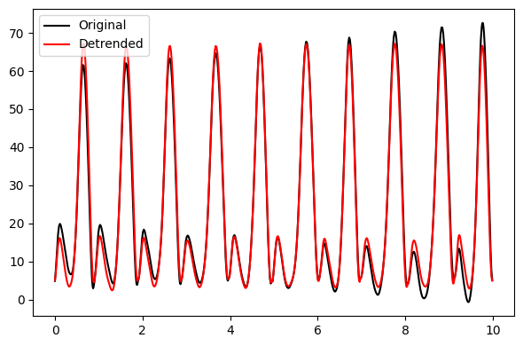

```python
fig = plt.figure(figsize=(6,4), tight_layout=True)
ax  = plt.axes()
ax.plot(t, y,  'k', label='Original')
ax.plot(t, yd, 'r', label='Detrended')
ax.legend()
plt.show()
```

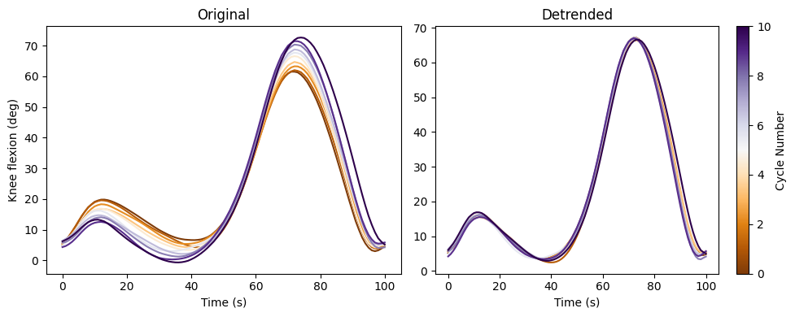

```python
fig,axs = plt.subplots(1, 2, figsize=(10,4), tight_layout=True)
ax0,ax1 = axs
fit.plot_registered(ax=ax0, cmap=plt.cm.PuOr)
fit.plot_detrended_registered( ax=ax1, cmap=plt.cm.PuOr, cbar=True)
[ax.set_xlabel('Time (s)')  for ax in axs]
[ax.set_title(s)  for ax,s in zip(axs, ['Original', 'Detrended'])]
ax0.set_ylabel('Knee flexion (deg)')
plt.show()
```